# Project_NLP_Twitter_US_Airline_Sentiment

```python
from google.colab import drive
drive.mount('/content/drive')
```

```python
!pip install contractions
```

**Importing Libraries**

```python
import re, string, unicodedata                          # Import Regex, string and unicodedata.
import contractions                                     # Import contractions library.
from bs4 import BeautifulSoup                           # Import BeautifulSoup.
import numpy as np
import pandas as pd
import os
from sklearn.decomposition import PCA
import warnings
warnings.filterwarnings('ignore')

import seaborn as sns
import matplotlib.pyplot as plt

import nltk                                             # Import Natural Language Tool-Kit.

nltk.download('stopwords')                              # Download Stopwords.
nltk.download('punkt')
nltk.download('wordnet')

from nltk.corpus import stopwords                       # Import stopwords.
from nltk.tokenize import word_tokenize, sent_tokenize  # Import Tokenizer.
from nltk.stem.wordnet import WordNetLemmatizer         # Import Lemmatizer.
```

**Load Dataset**

```python
tweets = pd.read_csv('/content/drive/MyDrive/NLP/PROJECT_AirlineTwitterSentiments/PROJECT/Tweets.csv')
```

**Display First Five Rows**

```python
tweets.head()
```

|  | tweet_id | airline_sentiment | airline_sentiment_confidence | negativereason | negativereason_confidence | airline | airline_sentiment_gold | name | negativereason_gold | retweet_count | text | tweet_coord | tweet_created | tweet_location | user_timezone |
| --- | --- | --- | --- | --- | --- | --- | --- | --- | --- | --- | --- | --- | --- | --- | --- |
| 0 | 570306133677760513 | neutral | 1.0000 | NaN | NaN | Virgin America | NaN | cairdin | NaN | 0 | @VirginAmerica What @dhepburn said. | NaN | 2015-02-24 11:35:52 -0800 | NaN | Eastern Time (US & Canada) |
| 1 | 570301130888122368 | positive | 0.3486 | NaN | 0.0000 | Virgin America | NaN | jnardino | NaN | 0 | @VirginAmerica plus you've added commercials to the experience... tacky. | NaN | 2015-02-24 11:15:59 -0800 | NaN | Pacific Time (US & Canada) |
| 2 | 570301083672813571 | neutral | 0.6837 | NaN | NaN | Virgin America | NaN | yvonnalynn | NaN | 0 | @VirginAmerica I didn't today... Must mean I need to take another trip! | NaN | 2015-02-24 11:15:48 -0800 | Lets Play | Central Time (US & Canada) |
| 3 | 570301031407624196 | negative | 1.0000 | Bad Flight | 0.7033 | Virgin America | NaN | jnardino | NaN | 0 | @VirginAmerica it's really aggressive to blast obnoxious "entertainment" in your guests' faces &amp; they have little recourse | NaN | 2015-02-24 11:15:36 -0800 | NaN | Pacific Time (US & Canada) |
| 4 | 570300817074462722 | negative | 1.0000 | Can't Tell | 1.0000 | Virgin America | NaN | jnardino | NaN | 0 | @VirginAmerica and it's a really big bad thing about it | NaN | 2015-02-24 11:14:45 -0800 | NaN | Pacific Time (US & Canada) |

**Print info, shape of data, description**

```python
tweets.info()
```

```
<class 'pandas.core.frame.DataFrame'>
RangeIndex: 14640 entries, 0 to 14639
Data columns (total 15 columns):
 #   Column                        Non-Null Count  Dtype
---  ------                        --------------  -----
 0   tweet_id                      14640 non-null  int64
 1   airline_sentiment             14640 non-null  object
 2   airline_sentiment_confidence  14640 non-null  float64
 3   negativereason                9178 non-null   object
 4   negativereason_confidence     10522 non-null  float64
 5   airline                       14640 non-null  object
 6   airline_sentiment_gold        40 non-null     object
 7   name                          14640 non-null  object
 8   negativereason_gold           32 non-null     object
 9   retweet_count                 14640 non-null  int64
 10  text                          14640 non-null  object
 11  tweet_coord                   1019 non-null   object
 12  tweet_created                 14640 non-null  object
 13  tweet_location                9907 non-null   object
 14  user_timezone                 9820 non-null   object
dtypes: float64(2), int64(2), object(11)
memory usage: 1.7+ MB
```

```python
tweets.shape
```

```
(14640, 15)
```

```python
tweets.dtypes
```

```
tweet_id                          int64
airline_sentiment                object
airline_sentiment_confidence    float64
negativereason                   object
negativereason_confidence       float64
airline                          object
airline_sentiment_gold           object
name                             object
negativereason_gold              object
retweet_count                     int64
text                             object
tweet_coord                      object
tweet_created                    object
tweet_location                   object
user_timezone                    object
dtype: object
```

```python
tweets.describe()
```

|  | tweet_id | airline_sentiment_confidence | negativereason_confidence | retweet_count |
| --- | --- | --- | --- | --- |
| count | 1.464000e+04 | 14640.000000 | 10522.000000 | 14640.000000 |
| mean | 5.692184e+17 | 0.900169 | 0.638298 | 0.082650 |
| std | 7.791112e+14 | 0.162830 | 0.330440 | 0.745778 |
| min | 5.675883e+17 | 0.335000 | 0.000000 | 0.000000 |
| 25% | 5.685592e+17 | 0.692300 | 0.360600 | 0.000000 |
| 50% | 5.694779e+17 | 1.000000 | 0.670600 | 0.000000 |
| 75% | 5.698905e+17 | 1.000000 | 1.000000 | 0.000000 |
| max | 5.703106e+17 | 1.000000 | 1.000000 | 44.000000 |

```python
#Number of sentiments in each category

tweets.airline_sentiment.value_counts()
```

```
negative    9178
neutral     3099
positive    2363
Name: airline_sentiment, dtype: int64
```

**Graphical Representation of Airline** **Sentiment**

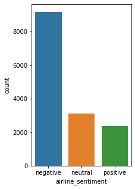

```python
plt.figure(figsize=(3,5))
#sns.countplot(tweets['airline_sentiment'], order =tweets.airline_sentiment.value_counts().index,palette= 'plasma')
sns.countplot(x='airline_sentiment',data=tweets,order=['negative','neutral','positive'])
plt.show()
```

**Graphical Representation of Airline Sentiment with Airlines**

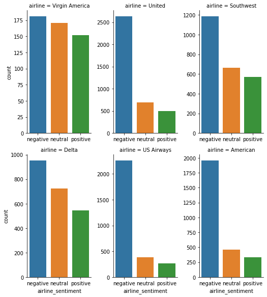

```python
sns.factorplot(x = 'airline_sentiment',data=tweets,
               order = ['negative','neutral','positive'],kind = 'count',col_wrap=3,col='airline',size=4,aspect=0.6,sharex=False,sharey=False)
plt.show()
```

```python
#Negative Reasons
tweets['negativereason'].value_counts()
```

```
Customer Service Issue         2910
Late Flight                    1665
Can't Tell                     1190
Cancelled Flight                847
Lost Luggage                    724
Bad Flight                      580
Flight Booking Problems         529
Flight Attendant Complaints     481
longlines                       178
Damaged Luggage                  74
Name: negativereason, dtype: int64
```

**Graphical representation of negativereason towards airlines:**

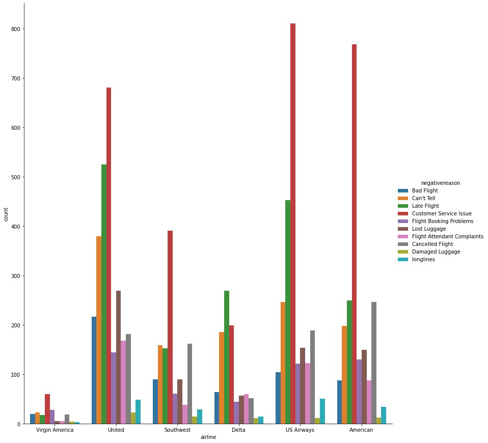

```python
sns.factorplot(x = 'airline',data = tweets,kind = 'count',hue='negativereason',size=12,aspect=.9)
plt.show()
```

The above and below graph are the same and show the negative comment reason for different airlines

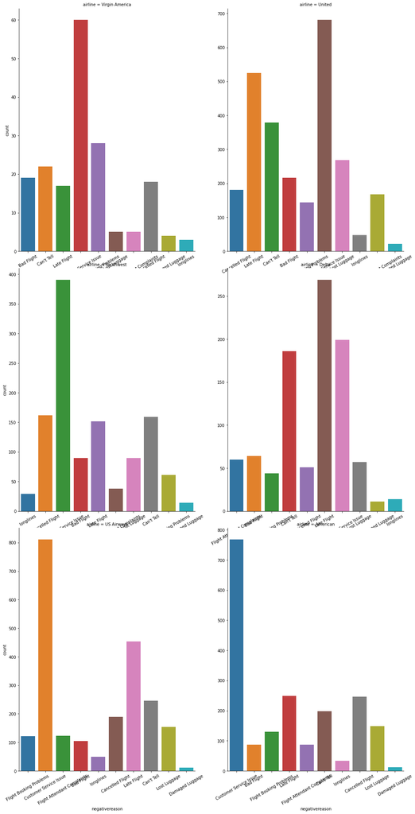

```python
g = sns.factorplot(x = 'negativereason',data=tweets,kind='count',col='airline',size=9,aspect=0.8,col_wrap=2,sharex=False,sharey=False)
# j_count = tweets['negativereason'].value_counts()
plt.rcParams["xtick.labelsize"] = 10
# ax = sns.barplot(j_count.index,j_count.values, alpha=0.9)
# ax.set_xticklabels(ax.get_xticklabels(), rotation=40, ha="right")
# plt.tight_layout()
g.set_xticklabels(rotation=30)
plt.show()
```

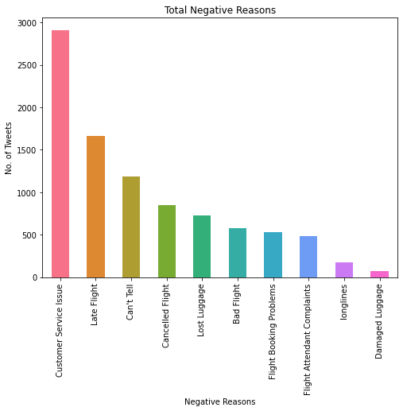

```python
#Plotting all the negative reasons
color=sns.color_palette("husl", 10)
pd.Series(tweets["negativereason"]).value_counts().plot(kind = "bar",
                        color=color,figsize=(8,6),title = "Total Negative Reasons")
plt.xlabel('Negative Reasons', fontsize=10)
plt.ylabel('No. of Tweets', fontsize=10)
```

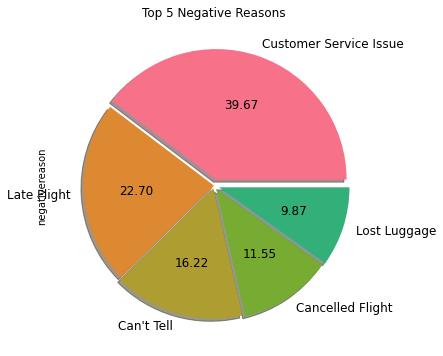

```python
color=sns.color_palette("husl", 10)
pd.Series(tweets["negativereason"]).value_counts().head(5).plot(kind="pie",
                labels=["Customer Service Issue", "Late Flight", "Can't Tell","Cancelled Flight","Lost Luggage"],
                colors=color,autopct='%.2f',explode=[0.05,0,0.02,0.03,0.04],shadow=True,
                fontsize=12,figsize=(6, 6),title="Top 5 Negative Reasons")
```

**Deleting all columns except "airline_sentiment" and "text"**

```python
# Creating new_tweets
new_tweets = tweets[['airline_sentiment','text']]
```

```python
# shape of new_tweets
new_tweets.shape
```

```
(14640, 2)
```

```python
# printing first five rows of new_tweets
new_tweets.head()
```

|  | airline_sentiment | text |
| --- | --- | --- |
| 0 | neutral | @VirginAmerica What @dhepburn said. |
| 1 | positive | @VirginAmerica plus you've added commercials to the experience... tacky. |
| 2 | neutral | @VirginAmerica I didn't today... Must mean I need to take another trip! |
| 3 | negative | @VirginAmerica it's really aggressive to blast obnoxious "entertainment" in your guests' faces &amp; they have little recourse |
| 4 | negative | @VirginAmerica and it's a really big bad thing about it |

```python
#Checking for any nul values
new_tweets.isnull().sum(axis=0)
```

```
airline_sentiment    0
text                 0
dtype: int64
```

```python
pd.set_option('display.max_colwidth',None)
new_tweets.head()
```

|  | airline_sentiment | text |
| --- | --- | --- |
| 0 | neutral | @VirginAmerica What @dhepburn said. |
| 1 | positive | @VirginAmerica plus you've added commercials to the experience... tacky. |
| 2 | neutral | @VirginAmerica I didn't today... Must mean I need to take another trip! |
| 3 | negative | @VirginAmerica it's really aggressive to blast obnoxious "entertainment" in your guests' faces &amp; they have little recourse |
| 4 | negative | @VirginAmerica and it's a really big bad thing about it |

**Text Pre-Processing and Data Preparation**

```python
# Remove html tags

def strip_html(text):
    soup = BeautifulSoup(text, "html.parser")
    return soup.get_text()

new_tweets['text'] = new_tweets['text'].apply(lambda x: strip_html(x))
new_tweets.head()
```

|  | airline_sentiment | text |
| --- | --- | --- |
| 0 | neutral | @VirginAmerica What @dhepburn said. |
| 1 | positive | @VirginAmerica plus you've added commercials to the experience... tacky. |
| 2 | neutral | @VirginAmerica I didn't today... Must mean I need to take another trip! |
| 3 | negative | @VirginAmerica it's really aggressive to blast obnoxious "entertainment" in your guests' faces & they have little recourse |
| 4 | negative | @VirginAmerica and it's a really big bad thing about it |

```python
# Replace contractions

def replace_contractions(text1):
    """Replace contractions in string of text"""
    return contractions.fix(text1)

new_tweets['text'] = new_tweets['text'].apply(lambda x: replace_contractions(x))
new_tweets.head()
```

|  | airline_sentiment | text |
| --- | --- | --- |
| 0 | neutral | @VirginAmerica What @dhepburn said. |
| 1 | positive | @VirginAmerica plus you have added commercials to the experience... tacky. |
| 2 | neutral | @VirginAmerica I did not today... Must mean I need to take another trip! |
| 3 | negative | @VirginAmerica it is really aggressive to blast obnoxious "entertainment" in your guests' faces & they have little recourse |
| 4 | negative | @VirginAmerica and it is a really big bad thing about it |

```python
# Remove numbers

def remove_numbers(text_1):
  text_1 = re.sub(r'\d+', '', text_1)
  return text_1

new_tweets['text'] = new_tweets['text'].apply(lambda x: remove_numbers(x))
new_tweets.head()
```

|  | airline_sentiment | text |
| --- | --- | --- |
| 0 | neutral | @VirginAmerica What @dhepburn said. |
| 1 | positive | @VirginAmerica plus you have added commercials to the experience... tacky. |
| 2 | neutral | @VirginAmerica I did not today... Must mean I need to take another trip! |
| 3 | negative | @VirginAmerica it is really aggressive to blast obnoxious "entertainment" in your guests' faces & they have little recourse |
| 4 | negative | @VirginAmerica and it is a really big bad thing about it |

```python
new_tweets['text'] = new_tweets.apply(lambda row: nltk.word_tokenize(row['text']), axis=1) # Tokenization of data
```

```python
new_tweets.head()
```

|  | airline_sentiment | text |
| --- | --- | --- |
| 0 | neutral | [@, VirginAmerica, What, @, dhepburn, said, .] |
| 1 | positive | [@, VirginAmerica, plus, you, have, added, commercials, to, the, experience, ..., tacky, .] |
| 2 | neutral | [@, VirginAmerica, I, did, not, today, ..., Must, mean, I, need, to, take, another, trip, !] |
| 3 | negative | [@, VirginAmerica, it, is, really, aggressive, to, blast, obnoxious, ``, entertainment, '', in, your, guests, ', faces, &, they, have, little, recourse] |
| 4 | negative | [@, VirginAmerica, and, it, is, a, really, big, bad, thing, about, it] |

```python
stopwords = stopwords.words('english')

customlist = ['not', "couldn't", 'didn', "didn't", 'doesn', "doesn't", 'hadn', "hadn't", 'hasn',
        "hasn't", 'haven', "haven't", 'isn', "isn't", 'ma', 'mightn', "mightn't", 'mustn',
        "mustn't", 'needn', "needn't", 'shan', "shan't", 'shouldn', "shouldn't", 'wasn',
        "wasn't", 'weren', "weren't", 'won', "won't", 'wouldn', "wouldn't"]

# Set custom stop-word's list as not, couldn't etc. words matter in Sentiment, so not removing them from original data.

stopwords = list(set(stopwords) - set(customlist))
```

```python
lemmatizer = WordNetLemmatizer()

def remove_non_ascii(words):
    """Remove non-ASCII characters from list of tokenized words"""
    new_words = []
    for word in words:
        new_word = unicodedata.normalize('NFKD', word).encode('ascii', 'ignore').decode('utf-8', 'ignore')
        new_words.append(new_word)
    return new_words

def to_lowercase(words):
    """Convert all characters to lowercase from list of tokenized words"""
    new_words = []
    for word in words:
        new_word = word.lower()
        new_words.append(new_word)
    return new_words

def remove_punctuation(words):
    """Remove punctuation from list of tokenized words"""
    new_words = []
    for word in words:
        new_word = re.sub(r'[^\w\s]', '', word)
        if new_word != '':
            new_words.append(new_word)
    return new_words

def remove_stopwords(words):
    """Remove stop words from list of tokenized words"""
    new_words = []
    for word in words:
        if word not in stopwords:
            new_words.append(word)
    return new_words

def lemmatize_list(words):
    new_words = []
    for word in words:
      new_words.append(lemmatizer.lemmatize(word, pos='v'))
    return new_words

def normalize(words):
    words = remove_non_ascii(words)
    words = to_lowercase(words)
    words = remove_punctuation(words)
    words = remove_stopwords(words)
    words = lemmatize_list(words)
    return ' '.join(words)

new_tweets['text'] = new_tweets.apply(lambda row: normalize(row['text']), axis=1)
new_tweets.head()
```

|  | airline_sentiment | text |
| --- | --- | --- |
| 0 | neutral | virginamerica dhepburn say |
| 1 | positive | virginamerica plus add commercials experience tacky |
| 2 | neutral | virginamerica not today must mean need take another trip |
| 3 | negative | virginamerica really aggressive blast obnoxious entertainment guests face little recourse |
| 4 | negative | virginamerica really big bad thing |

```python
new_tweets['airline_sentiment'] = new_tweets['airline_sentiment'].replace({'neutral': 0, 'positive': 1, 'negative': 2})
new_tweets.head()
```

|  | airline_sentiment | text |
| --- | --- | --- |
| 0 | 0 | virginamerica dhepburn say |
| 1 | 1 | virginamerica plus add commercials experience tacky |
| 2 | 0 | virginamerica not today must mean need take another trip |
| 3 | 2 | virginamerica really aggressive blast obnoxious entertainment guests face little recourse |
| 4 | 2 | virginamerica really big bad thing |

```python
labels = new_tweets['airline_sentiment']
labels = labels.astype('int')
labels.dtypes
```

```
dtype('int64')
```

```python
# Vectorization (Convert text data to numbers).
from sklearn.feature_extraction.text import CountVectorizer

vectorizer = CountVectorizer(max_features=1000)                # Keep only 1000 features as number of features will increase the processing time.
new_tweets_features = vectorizer.fit_transform(new_tweets['text'])

new_tweets_features = new_tweets_features.toarray()                        # Convert the data features to array.
```

```python
new_tweets_features.shape
```

```
(14640, 1000)
```